# Multimodal Analysis: Sample 191127_A00561_0111_AHHW5HDRXX

Ana Ferreira, Yoshi Koguchi

December 5th, 2019

#### 1. Load libraries and raw data

#### 2. Create Seurat Object with RNAseq count only

```
An object of class Seurat
33538 features across 7976 samples within 1 assay
Active assay: RNA (33538 features, 0 variable features)
```

#### 3. Add assays to Seurat Object, normalize and scale

I follow this [post](https://www.biostars.org/p/383217/) to add the contigs and clonotype information to the Seurat object. The basic strategy is to load the contigs file, edit by removing barcode sufix to match the Seurat’s object barcode name format, remove duplicated barcodes, edit the column containing the clonotypeID and merge this file with the clonotype csv file.

Here’s what is stored in the metadata for the Seurat object. We can add any information we want, as soon as the barcode for each cell matches our dataframe.

|  | orig.ident | nCount_RNA | nFeature_RNA |
| --- | --- | --- | --- |
| AAACCTGAGAAGGGTA-1 | vdj_totalseqC | 3134 | 1204 |
| AAACCTGAGACTGGGT-1 | vdj_totalseqC | 2510 | 1053 |
| AAACCTGAGCCCTAAT-1 | vdj_totalseqC | 2769 | 995 |
| AAACCTGAGGCCCGTT-1 | vdj_totalseqC | 3231 | 1359 |
| AAACCTGAGGTGACCA-1 | vdj_totalseqC | 1054 | 509 |
| AAACCTGCAAAGGTGC-1 | vdj_totalseqC | 3641 | 1357 |
| AAACCTGCAATGGAGC-1 | vdj_totalseqC | 3372 | 1452 |
| AAACCTGCACACCGAC-1 | vdj_totalseqC | 2650 | 1251 |
| AAACCTGCATAGGATA-1 | vdj_totalseqC | 1669 | 915 |
| AAACCTGCATCGATTG-1 | vdj_totalseqC | 12601 | 3131 |

[output cut: 990 more lines]

From the CellRanger vdj pipeline by 10x, we obtain multiple files containing important information about each cell alpha and beta pairing. Although, there are other methods available which we will explore later (GLIPH, TCRdist), for this initial integration analysis, we will work with the Cellranger output to obtain information about corresponding cells and their TCR rearrangement.

The *filtered contig* file contains the barcode and clonotypeID. We subset this file which contains 18 columns with detailed annotation on each high-confidence cellular contig. For more information on how CellRanger vdj pipeline operates, check this [link](https://support.10xgenomics.com/single-cell-vdj/software/pipelines/latest/algorithms/annotation#productive).

We use this dataframe for downstream analysis.

|  | barcode | clonotype_id |
| --- | --- | --- |
| 1 | AAACCTGAGAAGGGTA | clonotype176 |
| 3 | AAACCTGAGACTGGGT | clonotype64 |
| 4 | AAACCTGAGCCCTAAT | clonotype386 |
| 6 | AAACCTGCAATGGAGC | clonotype10 |
| 8 | AAACCTGCACACCGAC | clonotype4 |
| 10 | AAACCTGCATCGATTG | clonotype387 |

Load the *clonotype.csv* and merge files based on clonotypeID with the information we want from both files into the object (barcode for cell ID, productive top 10 clonotypes based on frequency and proportion).

|  | clonotype_id | frequency | proportion |
| --- | --- | --- | --- |
| 1 | clonotype1 | 85 | 0.017689906 |
| 2 | clonotype2 | 56 | 0.011654527 |
| 3 | clonotype3 | 43 | 0.008949011 |
| 4 | clonotype4 | 42 | 0.008740895 |
| 5 | clonotype5 | 40 | 0.008324662 |
| 6 | clonotype6 | 36 | 0.007492196 |
| 7 | clonotype7 | 32 | 0.006659729 |
| 8 | clonotype8 | 30 | 0.006243496 |
| 9 | clonotype9 | 28 | 0.005827263 |
| 10 | clonotype10 | 27 | 0.005619147 |

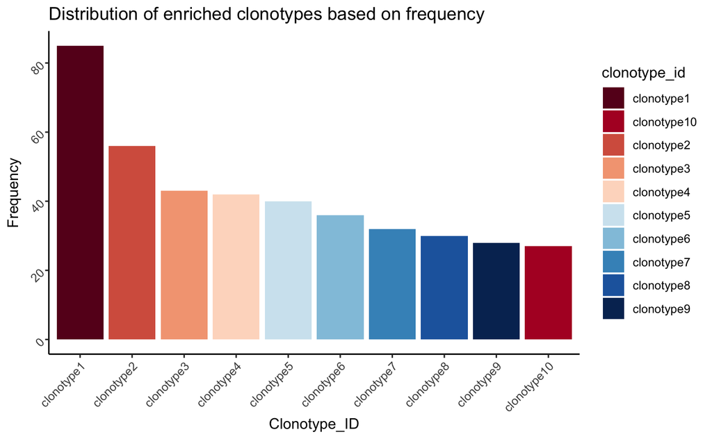

Merge all data and add to Seurat object

Clonotype information has been successfuly added to the metadata

In order to plot the distribution of the clonotypes on the UMAP, we first need to perform a few transformations, including changing from discrete to continuous data.

**Add an HTO as an independent assay and Normalize it with CLR (center-log ratio) method**

**Add the protein expression data to the Seurat object, normalize with the CLR method and scale it**

#### 4. Perform QC on RNA data (filter out low quality cells and dead cells)

After having normalized ADT data, now we start working on the RNAseq data and performing QC steps with Seurat3.

Let’s flag mithocondrial genes and remove them before we proceed with other analysis. This is the first step in Seurat’s suggested QC.

Initially, there are only nCount_RNA/ADT nFeature_RNA/ADT stored as metadata. We are going to add an extra column with the information about genes starting with -MT and filter out later on. Note that this metadata also contains the ADT assay information beside the newly added % mitochondrial information

**Distribution of genes**

*Before filtering step:*

**Using Pearson correlation to compare feature-feature relationships**

FeatureScatter is typically used to visualize feature-feature relationships, but can be used for anything calculated by the object, i.e. columns in object metadata, PC scores etc.

**Filtering step**

According to the Seurat’s vignette, the authors suggest filtering based on nFeature(genes) those cells that have unique feature counts. We will remove cells with gene counts over 2500 (doublets?) AND less than 200 (mRNA in solution) AND cells that have >5% mitochondrial counts (apoptotic). For a full discussion of the metrics used here, check out Seurat’s clustering [vignette](https://satijalab.org/seurat/v3.1/pbmc3k_tutorial.html) and the [paper](https://www.ncbi.nlm.nih.gov/pmc/articles/PMC4758103/) by *Ilicic et al*.

*After filtering step:*

#### 5. Apply the sctransform normalization on **RNAseq data only** (others have already been normalized)

“Improved methods for normalization. Seurat v3 includes support for sctransform, a new modeling approach for the normalization of single-cell data, described in a second [preprint](https://www.biorxiv.org/content/10.1101/576827v2). Compared to standard log-normalization, sctransform effectively removes technically-driven variation while preserving biological heterogeneity.”

“This single command replaces NormalizeData, ScaleData, and FindVariableFeatures from version2. Transformed data will be available in the SCT assay, which is set as the default after running sctransform. During normalization, we can also remove confounding sources of variation, for example, mitochondrial mapping percentage. The FindVariableFeatures in Seurat2 (here applied as part of the sctransform function) aims to calculate a subset of features that exhibit high cell-to-cell variation in the dataset - highly expressed in some cells and lowly expressed in others. By focusing on these genes in downstream analysis helps highlight biological signal in single cell datasets.”"

#### 6. List highly expressed genes

Plot variable features from gene expression: Identifies features that are outliers on a ‘mean variability plot’. These genes have higher Residual variance when compared to the rest of the genes in the RNA dataset. Later in the analysis, we will investigate if these genes map to a specific cell population and what that means biologically.

There are two immunoglobulin genes highly expressed in this dataset:IGKC, IGHG1 which are produced by B cells and we might want to look into it a bit further with a package called [soupX](https://www.biorxiv.org/content/10.1101/303727v1). In a nuthsell, gene expression from cells that are known for not expressing these genes will be corrected. It basically removes ambient RNA contamination from droplet-based experiments.

#### 7. Perform linear dimensionality reduction (PCA) and include diagnostics for choosing the PCs of the new data

"Identifying the true dimensionality of a dataset can be challenging/uncertain. We therefore suggest these three approaches to consider. The first is more supervised, exploring PCs with *RunPCA* function to determine relevant sources of heterogeneity, and could be used in conjunction with GSEA for example.

The second, *JackStrawMethod* implements a statistical test based on a random null model, but is time-consuming for large datasets, and may not return a clear PC cutoff.

The third *ElbowPlot* is a heuristic that is commonly used, and can be calculated instantly.

Anything between PC 7-12 as a cutoff is justifiable."

*First, perform linear dimensional reduction with PCA on the scaled data.*

"The *JackStrawPlot* function provides a visualization tool for comparing the distribution of p-values for each PC with a uniform distribution (dashed line). ‘Significant’ PCs will show a strong enrichment of features with low p-values (solid curve above the dashed line).

Significant PCs should show a p-value distribution (black curve) that is strongly skewed to the left compared to the null distribution (dashed line) The p-value for each PC is based on a proportion test comparing the number of genes with a p-value below a particular threshold (score.thresh), compared with the proportion of genes expected under a uniform distribution of p-values."

“A DimHeatmap allows for easy exploration of the primary sources of heterogeneity in a dataset, and can be useful when trying to decide which PCs to include for further downstream analyses. Both cells and features are ordered according to their PCA scores. Setting cells to a number plots the ‘extreme’ cells on both ends of the spectrum, which dramatically speeds plotting for large datasets. Though clearly a supervised analysis, we find this to be a valuable tool for exploring correlated feature sets.This type of graph allows us to visualize sources of heterogeneity in the dataset.”